# R Notebook

Question 1

Load in the dataset and call it drinks_content, eyeball it by printing it out (first 5 rows, last 5 rows, and then all of the data) and find out the dimensions (number of rows/columns) and variable names.

```r
library(tidyverse)
```

[output not shown]

[output cut: 232 more lines]

Question 2

Calculate some quick summary statistics to check the mean and the variance of the Calories variable. Also create a histogram of the Calories variable. Write a quick summary of your initial impressions of the data.

```r
var(drinks_content$Calories)
```

```
[1] 10580.86
```

Histogram of the Calories Variable

[figure not shown]

```r
summary(drinks_content)
```

```
 Beverage_category    Beverage         Beverage_prep         Calories
 Length:242         Length:242         Length:242         Min.   :  0.0
 Class :character   Class :character   Class :character   1st Qu.:120.0
 Mode  :character   Mode  :character   Mode  :character   Median :185.0
                                                          Mean   :193.9
                                                          3rd Qu.:260.0
                                                          Max.   :510.0
 Total Fat (g)      Trans Fat (g)   Saturated Fat (g)  Sodium (mg)
 Length:242         Min.   :0.000   Min.   :0.0000    Min.   : 0.000
 Class :character   1st Qu.:0.100   1st Qu.:0.0000    1st Qu.: 0.000
 Mode  :character   Median :0.500   Median :0.0000    Median : 5.000
                    Mean   :1.307   Mean   :0.0376    Mean   : 6.364
                    3rd Qu.:2.000   3rd Qu.:0.1000    3rd Qu.:10.000
                    Max.   :9.000   Max.   :0.3000    Max.   :40.000
 Total Carbohydrates (g) Cholesterol (mg) Dietary Fibre (g)   Sugars (g)
 Min.   :  0.0           Min.   : 0.00    Min.   :0.0000    Min.   : 0.00
 1st Qu.: 70.0           1st Qu.:21.00    1st Qu.:0.0000    1st Qu.:18.00
 Median :125.0           Median :34.00    Median :0.0000    Median :32.00
 Mean   :128.9           Mean   :35.99    Mean   :0.8058    Mean   :32.96
 3rd Qu.:170.0           3rd Qu.:50.75    3rd Qu.:1.0000    3rd Qu.:43.75
 Max.   :340.0           Max.   :90.00    Max.   :8.0000    Max.   :84.00
  Protein (g)     Vitamin A (% DV)   Vitamin C (% DV)   Calcium (% DV)
 Min.   : 0.000   Length:242         Length:242         Length:242
 1st Qu.: 3.000   Class :character   Class :character   Class :character
 Median : 6.000   Mode  :character   Mode  :character   Mode  :character
 Mean   : 6.979
 3rd Qu.:10.000
 Max.   :20.000
 Iron (% DV)        Caffeine (mg)
 Length:242         Length:242
 Class :character   Class :character
 Mode  :character   Mode  :character
```

Question 3

Check if you have any outliers in the Calories variable by creating a boxplot. Then get the actual values of any outliers you have. Finally, decide what you want to do here. Do you want to remove the outliers? Do you want to keep them? Justify your decision either way. As you work through your outlier identification and removal process, write a summary of what you find (i.e. do you find any outliers), what you decide to do (why you are removing them or not, what criteria you might use), and how you removed them if you did (e.g. did you remove all or not).

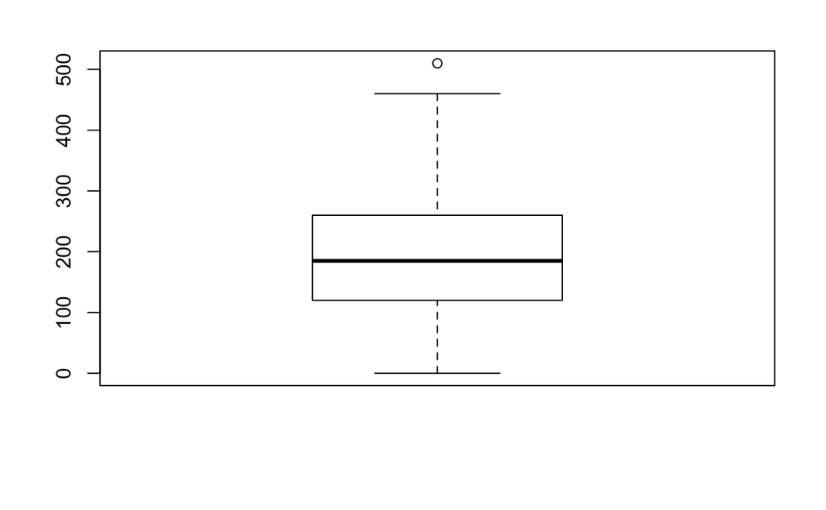

```r
boxplot(drinks_content$Calories)
```

Ans : Yes we have one outlier with Calorie Value 510, but would like to keep the data set as its not a very huge deviation from the next closest at 460..

Question 4

Select the variables beverage_category, beverage, beverage prep and calories from your data. Since we are interested in the calorie content, check if there are any NA values in the data, and drop them if there are.

```r
select(drinks_content, Beverage_category, Beverage, Beverage_prep, Calories)
```

| Beverage_category | Beverage | Beverage_prep | Calories |
| --- | --- | --- | --- |
| Coffee | Brewed Coffee | Short | 3 |
| Coffee | Brewed Coffee | Tall | 4 |
| Coffee | Brewed Coffee | Grande | 5 |
| Coffee | Brewed Coffee | Venti | 5 |
| Classic Espresso Drinks | Caffè Latte | Short Nonfat Milk | 70 |
| Classic Espresso Drinks | Caffè Latte | 2% Milk | 100 |
| Classic Espresso Drinks | Caffè Latte | Soymilk | 70 |
| Classic Espresso Drinks | Caffè Latte | Tall Nonfat Milk | 100 |
| Classic Espresso Drinks | Caffè Latte | 2% Milk | 150 |
| Classic Espresso Drinks | Caffè Latte | Soymilk | 110 |

[output cut: 232 more lines]

Question 5

Filter the data so we only take “classic espresso drinks”.

```r
filter(drinks_content, Beverage_category == "Classic Espresso Drinks")
```

| Beverage_category | Beverage | Beverage_prep | Calories | Total Fat (g) | Trans Fat (g) | Saturated Fat (g) | Sodium (mg) | Total Carbohydrates (g) | Cholesterol (mg) | Dietary Fibre (g) | Sugars (g) | Protein (g) | Vitamin A (% DV) | Vitamin C (% DV) | Calcium (% DV) | Iron (% DV) | Caffeine (mg) |
| --- | --- | --- | --- | --- | --- | --- | --- | --- | --- | --- | --- | --- | --- | --- | --- | --- | --- |
| Classic Espresso Drinks | Caffè Latte | Short Nonfat Milk | 70 | 0.1 | 0.1 | 0.0 | 5 | 75 | 10 | 0 | 9 | 6.0 | 10% | 0% | 20% | 0% | 75 |
| Classic Espresso Drinks | Caffè Latte | 2% Milk | 100 | 3.5 | 2.0 | 0.1 | 15 | 85 | 10 | 0 | 9 | 6.0 | 10% | 0% | 20% | 0% | 75 |
| Classic Espresso Drinks | Caffè Latte | Soymilk | 70 | 2.5 | 0.4 | 0.0 | 0 | 65 | 6 | 1 | 4 | 5.0 | 6% | 0% | 20% | 8% | 75 |
| Classic Espresso Drinks | Caffè Latte | Tall Nonfat Milk | 100 | 0.2 | 0.2 | 0.0 | 5 | 120 | 15 | 0 | 14 | 10.0 | 15% | 0% | 30% | 0% | 75 |
| Classic Espresso Drinks | Caffè Latte | 2% Milk | 150 | 6 | 3.0 | 0.2 | 25 | 135 | 15 | 0 | 14 | 10.0 | 15% | 0% | 30% | 0% | 75 |
| Classic Espresso Drinks | Caffè Latte | Soymilk | 110 | 4.5 | 0.5 | 0.0 | 0 | 105 | 10 | 1 | 6 | 8.0 | 10% | 0% | 30% | 15% | 75 |
| Classic Espresso Drinks | Caffè Latte | Grande Nonfat Milk | 130 | 0.3 | 0.2 | 0.0 | 5 | 150 | 19 | 0 | 18 | 13.0 | 20% | 0% | 40% | 0% | 150 |
| Classic Espresso Drinks | Caffè Latte | 2% Milk | 190 | 7 | 3.5 | 0.2 | 30 | 170 | 19 | 0 | 17 | 12.0 | 20% | 2% | 40% | 0% | 150 |
| Classic Espresso Drinks | Caffè Latte | Soymilk | 150 | 5 | 0.5 | 0.0 | 0 | 130 | 13 | 1 | 8 | 10.0 | 15% | 0% | 40% | 15% | 150 |
| Classic Espresso Drinks | Caffè Latte | Venti Nonfat Milk | 170 | 0.4 | 0.3 | 0.0 | 10 | 190 | 25 | 0 | 23 | 16.0 | 30% | 0% | 50% | 0% | 150 |

[output cut: 48 more lines]

```r
NA
NA
```

Question 6

Create a new tibble called drink_calories which contains a variable called calorie_diff. calorie_diff should store the difference between 135 calories (135 calories = 10 cubes of sugar!) and the calories in each drink. (hint: you’ll want to subtract the calories from 135 to see which drink have more or less than 10 cups of sugar).

```r
drink_calories <- mutate(drinks_content,
                         calorie_diff = 135 - Calories,
                         More_than_ten_cubes_of_Sugar = Calories > 135)

drink_calories
```

| Beverage_category | Beverage | Beverage_prep | Calories | Total Fat (g) | Trans Fat (g) | Saturated Fat (g) | Sodium (mg) | Total Carbohydrates (g) | Cholesterol (mg) | Dietary Fibre (g) | Sugars (g) | Protein (g) | Vitamin A (% DV) | Vitamin C (% DV) | Calcium (% DV) | Iron (% DV) | Caffeine (mg) | calorie_diff | More_than_ten_cubes_of_Sugar |
| --- | --- | --- | --- | --- | --- | --- | --- | --- | --- | --- | --- | --- | --- | --- | --- | --- | --- | --- | --- |
| Coffee | Brewed Coffee | Short | 3 | 0.1 | 0.0 | 0.0 | 0 | 5 | 0 | 0 | 0 | 0.3 | 0% | 0% | 0% | 0% | 175 | 132 | FALSE |
| Coffee | Brewed Coffee | Tall | 4 | 0.1 | 0.0 | 0.0 | 0 | 10 | 0 | 0 | 0 | 0.5 | 0% | 0% | 0% | 0% | 260 | 131 | FALSE |
| Coffee | Brewed Coffee | Grande | 5 | 0.1 | 0.0 | 0.0 | 0 | 10 | 0 | 0 | 0 | 1.0 | 0% | 0% | 0% | 0% | 330 | 130 | FALSE |
| Coffee | Brewed Coffee | Venti | 5 | 0.1 | 0.0 | 0.0 | 0 | 10 | 0 | 0 | 0 | 1.0 | 0% | 0% | 2% | 0% | 410 | 130 | FALSE |
| Classic Espresso Drinks | Caffè Latte | Short Nonfat Milk | 70 | 0.1 | 0.1 | 0.0 | 5 | 75 | 10 | 0 | 9 | 6.0 | 10% | 0% | 20% | 0% | 75 | 65 | FALSE |
| Classic Espresso Drinks | Caffè Latte | 2% Milk | 100 | 3.5 | 2.0 | 0.1 | 15 | 85 | 10 | 0 | 9 | 6.0 | 10% | 0% | 20% | 0% | 75 | 35 | FALSE |
| Classic Espresso Drinks | Caffè Latte | Soymilk | 70 | 2.5 | 0.4 | 0.0 | 0 | 65 | 6 | 1 | 4 | 5.0 | 6% | 0% | 20% | 8% | 75 | 65 | FALSE |
| Classic Espresso Drinks | Caffè Latte | Tall Nonfat Milk | 100 | 0.2 | 0.2 | 0.0 | 5 | 120 | 15 | 0 | 14 | 10.0 | 15% | 0% | 30% | 0% | 75 | 35 | FALSE |
| Classic Espresso Drinks | Caffè Latte | 2% Milk | 150 | 6 | 3.0 | 0.2 | 25 | 135 | 15 | 0 | 14 | 10.0 | 15% | 0% | 30% | 0% | 75 | -15 | TRUE |
| Classic Espresso Drinks | Caffè Latte | Soymilk | 110 | 4.5 | 0.5 | 0.0 | 0 | 105 | 10 | 1 | 6 | 8.0 | 10% | 0% | 30% | 15% | 75 | 25 | FALSE |

[output cut: 232 more lines]

```r
view(drink_calories)
```

Question 7

Create a new tibble called drinks_grouped where you group your data by the type of beverage prep. Then summarise the mean calories in each drink (by group) in a variable called mean_cal, and save it to drinks_summary. Finally arrange this summary data in descending order of mean calories.

```r
drinks_summary_mean_cal <- mutate(drinks_summary, mean_cal = char_count/2)
```

```
Error: object 'char_count' not found
```

Question 8

Hopefully you can see by now how much hassle it can be to constantly keep creating tibbles to store all your data. Finish up by using the %>% operator to put all the answers you’ve got from questions 4-7 into one pipe. You don’t need to include the check for NA values in this, as you’d typically check that before you start doing any analysis.

```r
drinks_grouped_piped <- drinks_content %>%

  group_by(Beverage_prep) %>%

  summarise(char_count = n()) %>%

  mutate(mean_cal = char_count/2)  %>%

  arrange(desc(mean_cal))

drinks_grouped_piped
```

| Beverage_prep | char_count | mean_cal |
| --- | --- | --- |
| Soymilk | 66 | 33.0 |
| 2% Milk | 50 | 25.0 |
| Grande Nonfat Milk | 26 | 13.0 |
| Tall Nonfat Milk | 23 | 11.5 |
| Venti Nonfat Milk | 22 | 11.0 |
| Whole Milk | 16 | 8.0 |
| Short Nonfat Milk | 12 | 6.0 |
| Grande | 7 | 3.5 |
| Tall | 7 | 3.5 |
| Venti | 7 | 3.5 |

[output cut: 3 more lines]

```r
NA
NA
NA
NA
NA
NA
```

Question 9

Use the drink_calories data to find the two drinks (Beverage) with least and most Calories.

```r
drink_calories
```

| Beverage_category | Beverage | Beverage_prep | Calories | Total Fat (g) | Trans Fat (g) | Saturated Fat (g) | Sodium (mg) | Total Carbohydrates (g) | Cholesterol (mg) | Dietary Fibre (g) | Sugars (g) | Protein (g) | Vitamin A (% DV) | Vitamin C (% DV) | Calcium (% DV) | Iron (% DV) | Caffeine (mg) | calorie_diff | More_than_ten_cubes_of_Sugar |
| --- | --- | --- | --- | --- | --- | --- | --- | --- | --- | --- | --- | --- | --- | --- | --- | --- | --- | --- | --- |
| Coffee | Brewed Coffee | Short | 3 | 0.1 | 0.0 | 0.0 | 0 | 5 | 0 | 0 | 0 | 0.3 | 0% | 0% | 0% | 0% | 175 | 132 | FALSE |
| Coffee | Brewed Coffee | Tall | 4 | 0.1 | 0.0 | 0.0 | 0 | 10 | 0 | 0 | 0 | 0.5 | 0% | 0% | 0% | 0% | 260 | 131 | FALSE |
| Coffee | Brewed Coffee | Grande | 5 | 0.1 | 0.0 | 0.0 | 0 | 10 | 0 | 0 | 0 | 1.0 | 0% | 0% | 0% | 0% | 330 | 130 | FALSE |
| Coffee | Brewed Coffee | Venti | 5 | 0.1 | 0.0 | 0.0 | 0 | 10 | 0 | 0 | 0 | 1.0 | 0% | 0% | 2% | 0% | 410 | 130 | FALSE |
| Classic Espresso Drinks | Caffè Latte | Short Nonfat Milk | 70 | 0.1 | 0.1 | 0.0 | 5 | 75 | 10 | 0 | 9 | 6.0 | 10% | 0% | 20% | 0% | 75 | 65 | FALSE |
| Classic Espresso Drinks | Caffè Latte | 2% Milk | 100 | 3.5 | 2.0 | 0.1 | 15 | 85 | 10 | 0 | 9 | 6.0 | 10% | 0% | 20% | 0% | 75 | 35 | FALSE |
| Classic Espresso Drinks | Caffè Latte | Soymilk | 70 | 2.5 | 0.4 | 0.0 | 0 | 65 | 6 | 1 | 4 | 5.0 | 6% | 0% | 20% | 8% | 75 | 65 | FALSE |
| Classic Espresso Drinks | Caffè Latte | Tall Nonfat Milk | 100 | 0.2 | 0.2 | 0.0 | 5 | 120 | 15 | 0 | 14 | 10.0 | 15% | 0% | 30% | 0% | 75 | 35 | FALSE |
| Classic Espresso Drinks | Caffè Latte | 2% Milk | 150 | 6 | 3.0 | 0.2 | 25 | 135 | 15 | 0 | 14 | 10.0 | 15% | 0% | 30% | 0% | 75 | -15 | TRUE |
| Classic Espresso Drinks | Caffè Latte | Soymilk | 110 | 4.5 | 0.5 | 0.0 | 0 | 105 | 10 | 1 | 6 | 8.0 | 10% | 0% | 30% | 15% | 75 | 25 | FALSE |

[output cut: 232 more lines]

```r
arrange(drink_calories, Calories)
```

| Beverage_category | Beverage | Beverage_prep | Calories | Total Fat (g) | Trans Fat (g) | Saturated Fat (g) | Sodium (mg) | Total Carbohydrates (g) | Cholesterol (mg) | Dietary Fibre (g) | Sugars (g) | Protein (g) | Vitamin A (% DV) | Vitamin C (% DV) | Calcium (% DV) | Iron (% DV) | Caffeine (mg) | calorie_diff | More_than_ten_cubes_of_Sugar |
| --- | --- | --- | --- | --- | --- | --- | --- | --- | --- | --- | --- | --- | --- | --- | --- | --- | --- | --- | --- |
| Tazo® Tea Drinks | Tazo® Tea | Short | 0 | 0 | 0.0 | 0.0 | 0 | 0 | 0 | 0 | 0 | 0.0 | 0% | 0% | 0% | 0% | Varies | 135 | FALSE |
| Tazo® Tea Drinks | Tazo® Tea | Tall | 0 | 0 | 0.0 | 0.0 | 0 | 0 | 0 | 0 | 0 | 0.0 | 0% | 0% | 0% | 0% | Varies | 135 | FALSE |
| Tazo® Tea Drinks | Tazo® Tea | Grande | 0 | 0 | 0.0 | 0.0 | 0 | 0 | 0 | 0 | 0 | 0.0 | 0% | 0% | 0% | 0% | Varies | 135 | FALSE |
| Tazo® Tea Drinks | Tazo® Tea | Venti | 0 | 0 | 0.0 | 0.0 | 0 | 0 | 0 | 0 | 0 | 0.0 | 0% | 0% | 0% | 0% | Varies | 135 | FALSE |
| Coffee | Brewed Coffee | Short | 3 | 0.1 | 0.0 | 0.0 | 0 | 5 | 0 | 0 | 0 | 0.3 | 0% | 0% | 0% | 0% | 175 | 132 | FALSE |
| Coffee | Brewed Coffee | Tall | 4 | 0.1 | 0.0 | 0.0 | 0 | 10 | 0 | 0 | 0 | 0.5 | 0% | 0% | 0% | 0% | 260 | 131 | FALSE |
| Coffee | Brewed Coffee | Grande | 5 | 0.1 | 0.0 | 0.0 | 0 | 10 | 0 | 0 | 0 | 1.0 | 0% | 0% | 0% | 0% | 330 | 130 | FALSE |
| Coffee | Brewed Coffee | Venti | 5 | 0.1 | 0.0 | 0.0 | 0 | 10 | 0 | 0 | 0 | 1.0 | 0% | 0% | 2% | 0% | 410 | 130 | FALSE |
| Classic Espresso Drinks | Caffè Americano | Short | 5 | 0 | 0.0 | 0.0 | 0 | 5 | 1 | 0 | 0 | 0.4 | 0% | 0% | 0% | 0% | 75 | 130 | FALSE |
| Classic Espresso Drinks | Espresso | Solo | 5 | 0 | 0.0 | 0.0 | 0 | 0 | 1 | 0 | 0 | 0.4 | 0% | 0% | 0% | 0% | 75 | 130 | FALSE |

[output cut: 232 more lines]

```r
arrange(drink_calories, desc(Calories))
```

| Beverage_category | Beverage | Beverage_prep | Calories | Total Fat (g) | Trans Fat (g) | Saturated Fat (g) | Sodium (mg) | Total Carbohydrates (g) | Cholesterol (mg) | Dietary Fibre (g) | Sugars (g) | Protein (g) | Vitamin A (% DV) | Vitamin C (% DV) | Calcium (% DV) | Iron (% DV) | Caffeine (mg) | calorie_diff | More_than_ten_cubes_of_Sugar |
| --- | --- | --- | --- | --- | --- | --- | --- | --- | --- | --- | --- | --- | --- | --- | --- | --- | --- | --- | --- |
| Signature Espresso Drinks | White Chocolate Mocha (Without Whipped Cream) | 2% Milk | 510 | 15 | 9.0 | 0.2 | 35 | 330 | 77 | 0 | 74 | 19.0 | 20% | 4% | 60% | 2% | 150 | -375 | TRUE |
| Signature Espresso Drinks | White Chocolate Mocha (Without Whipped Cream) | Soymilk | 460 | 13 | 6.0 | 0.0 | 5 | 290 | 70 | 1 | 64 | 16.0 | 15% | 2% | 60% | 20% | 150 | -325 | TRUE |
| Frappuccino® Blended Coffee | Java Chip (Without Whipped Cream) | Whole Milk | 460 | 10 | 7.0 | 0.2 | 15 | 340 | 90 | 2 | 84 | 7.0 | 6% | 0% | 15% | 35% | 145 | -325 | TRUE |
| Signature Espresso Drinks | White Chocolate Mocha (Without Whipped Cream) | Venti Nonfat Milk | 450 | 7 | 6.0 | 0.0 | 10 | 310 | 78 | 0 | 74 | 19.0 | 25% | 2% | 60% | 2% | 150 | -315 | TRUE |
| Tazo® Tea Drinks | Tazo® Green Tea Latte | 2% Milk | 450 | 10 | 5.0 | 0.3 | 40 | 230 | 72 | 2 | 71 | 17.0 | 25% | 20% | 50% | 6% | 110 | -315 | TRUE |
| Frappuccino® Blended Coffee | Java Chip (Without Whipped Cream) | Soymilk | 430 | 8 | 4.5 | 0.0 | 0 | 330 | 88 | 3 | 80 | 6.0 | 6% | 0% | 20% | 40% | 145 | -295 | TRUE |
| Frappuccino® Blended Coffee | Java Chip (Without Whipped Cream) | Venti Nonfat Milk | 420 | 5 | 4.0 | 0.0 | 5 | 340 | 90 | 2 | 84 | 7.0 | 10% | 0% | 20% | 35% | 145 | -285 | TRUE |
| Signature Espresso Drinks | White Chocolate Mocha (Without Whipped Cream) | 2% Milk | 400 | 11 | 7.0 | 0.2 | 25 | 250 | 61 | 0 | 58 | 15.0 | 15% | 2% | 45% | 0% | 150 | -265 | TRUE |
| Tazo® Tea Drinks | Tazo® Green Tea Latte | Soymilk | 390 | 8 | 1.0 | 0.0 | 0 | 180 | 64 | 4 | 58 | 14.0 | 20% | 20% | 60% | 30% | 110 | -255 | TRUE |
| Frappuccino® Blended Coffee | Mocha (Without Whipped Cream) | Whole Milk | 390 | 6 | 3.5 | 0.1 | 15 | 300 | 80 | 1 | 76 | 6.0 | 8% | 0% | 15% | 10% | 140 | -255 | TRUE |

[output cut: 232 more lines]